# K-means clustering & Schools.csv

```python
import pandas as pd
import numpy as np
import matplotlib.pyplot as plt
import seaborn as sns
%matplotlib inline

from sklearn.cluster import KMeans

from sklearn.cluster import AgglomerativeClustering
from sklearn.metrics import pairwise_distances

from sklearn import tree
from sklearn.tree import DecisionTreeClassifier

from scipy.cluster.hierarchy import dendrogram, ward
```

# Import packages & data (schools.csv)

```python
df = pd.read_csv('data/schools.csv')
df.head()
```

|  | School_Code | School_Name | Pct_First_Language_Not_English | Pct_English_Language_Learner | Pct_Students_With_Disabilities | Pct_High_Needs | Pct_Economically_Disadvantaged | Pct_African_American | Pct_Asian | Pct_Hispanic | Pct_White | Pct_Native_American | Pct_Native_Hawaiian_Pacific_Isla | Pct_MultiRace_NonHispanic | Pct_Males | Pct_Females | Average_Class_Size |
| --- | --- | --- | --- | --- | --- | --- | --- | --- | --- | --- | --- | --- | --- | --- | --- | --- | --- |
| 0 | 10505.0 | Abington High | 5.3 | 2.4 | 9.7 | 28.8 | 21.5 | 2.2 | 1.5 | 9.1 | 85.8 | 0.2 | 0.2 | 0.9 | 45.6 | 54.4 | 15.8 |
| 1 | 10003.0 | Beaver Brook Elementary School | 10.5 | 7.2 | 13.3 | 37.1 | 23.3 | 1.9 | 1.9 | 6.7 | 88.4 | 0.5 | 0.2 | 0.3 | 50.2 | 49.8 | 24.6 |
| 2 | 10002.0 | Center Elementary School | 12.8 | 3.0 | 21.2 | 34.0 | 16.3 | 3.9 | 3.0 | 8.4 | 84.7 | 0.0 | 0.0 | 0.0 | 54.2 | 45.8 | 14.6 |
| 3 | 10405.0 | Frolio Middle School | 5.5 | 1.8 | 13.1 | 30.8 | 21.6 | 2.4 | 1.8 | 6.1 | 89.3 | 0.0 | 0.0 | 0.3 | 53.4 | 46.6 | 21.1 |
| 4 | 10015.0 | Woodsdale Elementary School | 5.9 | 2.0 | 10.8 | 30.6 | 22.7 | 2.0 | 1.4 | 4.2 | 92.1 | 0.0 | 0.0 | 0.3 | 50.7 | 49.3 | 30.4 |

```python
df.info()
```

```
<class 'pandas.core.frame.DataFrame'>
RangeIndex: 1861 entries, 0 to 1860
Data columns (total 17 columns):
 #   Column                            Non-Null Count  Dtype
---  ------                            --------------  -----
 0   School_Code                       1861 non-null   float64
 1   School_Name                       1861 non-null   object
 2   Pct_First_Language_Not_English    1850 non-null   float64
 3   Pct_English_Language_Learner      1850 non-null   float64
 4   Pct_Students_With_Disabilities    1850 non-null   float64
 5   Pct_High_Needs                    1850 non-null   float64
 6   Pct_Economically_Disadvantaged    1850 non-null   float64
 7   Pct_African_American              1850 non-null   float64
 8   Pct_Asian                         1850 non-null   float64
 9   Pct_Hispanic                      1850 non-null   float64
 10  Pct_White                         1850 non-null   float64
 11  Pct_Native_American               1850 non-null   float64
 12  Pct_Native_Hawaiian_Pacific_Isla  1850 non-null   float64
 13  Pct_MultiRace_NonHispanic         1850 non-null   float64
 14  Pct_Males                         1850 non-null   float64
 15  Pct_Females                       1850 non-null   float64
 16  Average_Class_Size                1823 non-null   float64
dtypes: float64(16), object(1)
memory usage: 247.3+ KB
```

# Data Preparation

- Drop two columns ('School_Code', 'School_Name')
- Handle missing values

```python
# droppin columns
df.drop(columns=['School_Code','School_Name'],axis=1, inplace=True)
```

```python
df.head()
```

|  | Pct_First_Language_Not_English | Pct_English_Language_Learner | Pct_Students_With_Disabilities | Pct_High_Needs | Pct_Economically_Disadvantaged | Pct_African_American | Pct_Asian | Pct_Hispanic | Pct_White | Pct_Native_American | Pct_Native_Hawaiian_Pacific_Isla | Pct_MultiRace_NonHispanic | Pct_Males | Pct_Females | Average_Class_Size |
| --- | --- | --- | --- | --- | --- | --- | --- | --- | --- | --- | --- | --- | --- | --- | --- |
| 0 | 5.3 | 2.4 | 9.7 | 28.8 | 21.5 | 2.2 | 1.5 | 9.1 | 85.8 | 0.2 | 0.2 | 0.9 | 45.6 | 54.4 | 15.8 |
| 1 | 10.5 | 7.2 | 13.3 | 37.1 | 23.3 | 1.9 | 1.9 | 6.7 | 88.4 | 0.5 | 0.2 | 0.3 | 50.2 | 49.8 | 24.6 |
| 2 | 12.8 | 3.0 | 21.2 | 34.0 | 16.3 | 3.9 | 3.0 | 8.4 | 84.7 | 0.0 | 0.0 | 0.0 | 54.2 | 45.8 | 14.6 |
| 3 | 5.5 | 1.8 | 13.1 | 30.8 | 21.6 | 2.4 | 1.8 | 6.1 | 89.3 | 0.0 | 0.0 | 0.3 | 53.4 | 46.6 | 21.1 |
| 4 | 5.9 | 2.0 | 10.8 | 30.6 | 22.7 | 2.0 | 1.4 | 4.2 | 92.1 | 0.0 | 0.0 | 0.3 | 50.7 | 49.3 | 30.4 |

```python
df.isnull().sum() #Null values.
```

```
Pct_First_Language_Not_English      11
Pct_English_Language_Learner        11
Pct_Students_With_Disabilities      11
Pct_High_Needs                      11
Pct_Economically_Disadvantaged      11
Pct_African_American                11
Pct_Asian                           11
Pct_Hispanic                        11
Pct_White                           11
Pct_Native_American                 11
Pct_Native_Hawaiian_Pacific_Isla    11
Pct_MultiRace_NonHispanic           11
Pct_Males                           11
Pct_Females                         11
Average_Class_Size                  38
dtype: int64
```

```python
# drop rows with missing value using dropna()

df = df.dropna()
df.isnull().sum()
```

```
Pct_First_Language_Not_English      0
Pct_English_Language_Learner        0
Pct_Students_With_Disabilities      0
Pct_High_Needs                      0
Pct_Economically_Disadvantaged      0
Pct_African_American                0
Pct_Asian                           0
Pct_Hispanic                        0
Pct_White                           0
Pct_Native_American                 0
Pct_Native_Hawaiian_Pacific_Isla    0
Pct_MultiRace_NonHispanic           0
Pct_Males                           0
Pct_Females                         0
Average_Class_Size                  0
dtype: int64
```

# Perform variance analysis

- Explain why data normalization is necessary

```python
 df.var() #variance analysis which shows a large number of difference among the variables hence normalization is required and since we don't have a Y variable and the data is unclusterd.
```

```
Pct_First_Language_Not_English      404.383426
Pct_English_Language_Learner        174.065427
Pct_Students_With_Disabilities      124.524392
Pct_High_Needs                      527.478833
Pct_Economically_Disadvantaged      504.583759
Pct_African_American                185.179021
Pct_Asian                            76.950470
Pct_Hispanic                        512.353186
Pct_White                           877.534691
Pct_Native_American                   0.247437
Pct_Native_Hawaiian_Pacific_Isla      0.079760
Pct_MultiRace_NonHispanic             5.876525
Pct_Males                            25.421004
Pct_Females                          25.430093
Average_Class_Size                   15.736926
dtype: float64
```

# Normalize data & Check variance again

```python
X = (df - df.mean()) / (df.max() - df.min())
X.head()
```

|  | Pct_First_Language_Not_English | Pct_English_Language_Learner | Pct_Students_With_Disabilities | Pct_High_Needs | Pct_Economically_Disadvantaged | Pct_African_American | Pct_Asian | Pct_Hispanic | Pct_White | Pct_Native_American | Pct_Native_Hawaiian_Pacific_Isla | Pct_MultiRace_NonHispanic | Pct_Males | Pct_Females | Average_Class_Size |
| --- | --- | --- | --- | --- | --- | --- | --- | --- | --- | --- | --- | --- | --- | --- | --- |
| 0 | -0.13276 | -0.086390 | -0.084592 | -0.177116 | -0.108704 | -0.080131 | -0.061879 | -0.100950 | 0.23435 | -0.003895 | 0.016897 | -0.155412 | -0.082948 | 0.083022 | -0.064465 |
| 1 | -0.08076 | -0.028489 | -0.048592 | -0.094116 | -0.089636 | -0.083857 | -0.056452 | -0.125440 | 0.26035 | 0.033605 | 0.016897 | -0.189895 | -0.022422 | 0.022495 | 0.160599 |
| 2 | -0.05776 | -0.079152 | 0.030408 | -0.125116 | -0.163789 | -0.059013 | -0.041527 | -0.108093 | 0.22335 | -0.028895 | -0.015890 | -0.207136 | 0.030210 | -0.030136 | -0.095155 |
| 3 | -0.13076 | -0.093627 | -0.050592 | -0.157116 | -0.107645 | -0.077646 | -0.057809 | -0.131563 | 0.26935 | -0.028895 | -0.015890 | -0.189895 | 0.019683 | -0.019610 | 0.071085 |
| 4 | -0.12676 | -0.091215 | -0.073592 | -0.159116 | -0.095992 | -0.082615 | -0.063236 | -0.150950 | 0.29735 | -0.028895 | -0.015890 | -0.189895 | -0.015843 | 0.015917 | 0.308937 |

```python
X.var() #Normalised data the data looks mych
```

```
Pct_First_Language_Not_English      0.040438
Pct_English_Language_Learner        0.025328
Pct_Students_With_Disabilities      0.012452
Pct_High_Needs                      0.052748
Pct_Economically_Disadvantaged      0.056623
Pct_African_American                0.028576
Pct_Asian                           0.014167
Pct_Hispanic                        0.053348
Pct_White                           0.087753
Pct_Native_American                 0.003866
Pct_Native_Hawaiian_Pacific_Isla    0.002144
Pct_MultiRace_NonHispanic           0.019410
Pct_Males                           0.004401
Pct_Females                         0.004403
Average_Class_Size                  0.010294
dtype: float64
```

# Clustering analysis (k = 2): Include "random_state=0"

```python
k_means = KMeans(init='k-means++',
                 n_init='auto',
                 n_clusters=2,
                 random_state=0)
```

```python
k_means.fit(df)
```

```
KMeans(n_clusters=2, random_state=0)
```

```python
#clustering results
k_means.labels_
```

```
array([0, 0, 0, ..., 1, 0, 1], dtype=int32)
```

```python
#cluster centroids or centers
k_means.cluster_centers_
```

```
array([[ 8.84325581,  3.55224806, 16.82054264, 34.33317829, 20.26790698,
         3.60844961,  5.94364341,  7.33922481, 79.04689922,  0.23666667,
         0.09341085,  3.73302326, 51.47124031, 48.52162791, 18.28891473],
       [42.13189493, 24.10619137, 21.39924953, 75.98667917, 59.57954972,
        20.85365854,  6.34333959, 47.19868668, 21.99043152,  0.21782364,
         0.1054409 ,  3.29230769, 52.95159475, 47.04652908, 18.39718574]])
```

```python
#To add cluster label into the dataset as a column
df1 = pd.DataFrame(k_means.labels_, columns = ['cluster'])
df1.head()
```

|  | cluster |
| --- | --- |
| 0 | 0 |
| 1 | 0 |
| 2 | 0 |
| 3 | 0 |
| 4 | 0 |

```python
df2 = df.join(df1)
df2.head()
```

|  | Pct_First_Language_Not_English | Pct_English_Language_Learner | Pct_Students_With_Disabilities | Pct_High_Needs | Pct_Economically_Disadvantaged | Pct_African_American | Pct_Asian | Pct_Hispanic | Pct_White | Pct_Native_American | Pct_Native_Hawaiian_Pacific_Isla | Pct_MultiRace_NonHispanic | Pct_Males | Pct_Females | Average_Class_Size | cluster |
| --- | --- | --- | --- | --- | --- | --- | --- | --- | --- | --- | --- | --- | --- | --- | --- | --- |
| 0 | 5.3 | 2.4 | 9.7 | 28.8 | 21.5 | 2.2 | 1.5 | 9.1 | 85.8 | 0.2 | 0.2 | 0.9 | 45.6 | 54.4 | 15.8 | 0.0 |
| 1 | 10.5 | 7.2 | 13.3 | 37.1 | 23.3 | 1.9 | 1.9 | 6.7 | 88.4 | 0.5 | 0.2 | 0.3 | 50.2 | 49.8 | 24.6 | 0.0 |
| 2 | 12.8 | 3.0 | 21.2 | 34.0 | 16.3 | 3.9 | 3.0 | 8.4 | 84.7 | 0.0 | 0.0 | 0.0 | 54.2 | 45.8 | 14.6 | 0.0 |
| 3 | 5.5 | 1.8 | 13.1 | 30.8 | 21.6 | 2.4 | 1.8 | 6.1 | 89.3 | 0.0 | 0.0 | 0.3 | 53.4 | 46.6 | 21.1 | 0.0 |
| 4 | 5.9 | 2.0 | 10.8 | 30.6 | 22.7 | 2.0 | 1.4 | 4.2 | 92.1 | 0.0 | 0.0 | 0.3 | 50.7 | 49.3 | 30.4 | 0.0 |

```python
df2.tail()
```

|  | Pct_First_Language_Not_English | Pct_English_Language_Learner | Pct_Students_With_Disabilities | Pct_High_Needs | Pct_Economically_Disadvantaged | Pct_African_American | Pct_Asian | Pct_Hispanic | Pct_White | Pct_Native_American | Pct_Native_Hawaiian_Pacific_Isla | Pct_MultiRace_NonHispanic | Pct_Males | Pct_Females | Average_Class_Size | cluster |
| --- | --- | --- | --- | --- | --- | --- | --- | --- | --- | --- | --- | --- | --- | --- | --- | --- |
| 1855 | 16.1 | 15.0 | 31.1 | 89.1 | 81.3 | 21.2 | 0.5 | 69.4 | 3.1 | 1.0 | 0.0 | 4.7 | 51.3 | 48.7 | 20.3 | NaN |
| 1856 | 51.2 | 25.5 | 11.5 | 53.4 | 28.9 | 35.1 | 11.5 | 21.1 | 29.8 | 1.2 | 0.0 | 1.2 | 45.0 | 55.0 | 18.8 | NaN |
| 1857 | 25.8 | 25.8 | 4.3 | 76.7 | 70.6 | 24.5 | 1.8 | 64.4 | 6.1 | 0.0 | 0.0 | 3.1 | 50.9 | 49.1 | 27.0 | NaN |
| 1858 | 6.2 | 2.1 | 20.4 | 49.9 | 36.1 | 6.3 | 3.3 | 12.2 | 70.5 | 0.4 | 0.2 | 7.1 | 43.4 | 56.6 | 25.7 | NaN |
| 1859 | 38.3 | 21.1 | 19.5 | 78.0 | 63.2 | 56.7 | 1.6 | 38.0 | 1.1 | 0.4 | 0.0 | 2.2 | 49.2 | 50.8 | 21.9 | NaN |

# Interpretation of Clustering Analysis

- When you answer the following questions below, use the original data (not the normalized data) for better interpretability

## How many observations are there in cluster 1 and cluster 2?

```python
df2['cluster'].value_counts()
```

```
cluster
0.0    1271
1.0     520
Name: count, dtype: int64
```

## The mean values of each cluster in terms of different variables (e.g., Pct_High_Needs)

```python
df2.groupby('cluster').mean()
```

| cluster | Pct_First_Language_Not_English | Pct_English_Language_Learner | Pct_Students_With_Disabilities | Pct_High_Needs | Pct_Economically_Disadvantaged | Pct_African_American | Pct_Asian | Pct_Hispanic | Pct_White | Pct_Native_American | Pct_Native_Hawaiian_Pacific_Isla | Pct_MultiRace_NonHispanic | Pct_Males | Pct_Females | Average_Class_Size |
| --- | --- | --- | --- | --- | --- | --- | --- | --- | --- | --- | --- | --- | --- | --- | --- |
| 0.0 | 12.760582 | 5.863336 | 17.626436 | 39.555704 | 25.222581 | 5.219827 | 5.931707 | 12.689300 | 72.140283 | 0.231471 | 0.095673 | 3.691739 | 51.758615 | 48.234697 | 18.280488 |
| 1.0 | 31.690962 | 17.871538 | 19.532885 | 62.185385 | 46.490577 | 16.506923 | 6.408846 | 33.303462 | 40.076923 | 0.234231 | 0.102692 | 3.371346 | 52.426538 | 47.570192 | 18.376346 |

## What is the profile of each cluster?

Profiling

- cluster 0: high english speakers and low learners with low needs and low in case of economic disadvantage with more whites and low african americans,asians and hispanics.
- cluster 1: Low english speakers, high learners who have high needs are economically highly disadvantaged consisting of low whites compared to cluster 0 and hight african americans, hispanics and asians.

## The mean values for"Pct_African_American" in each cluster. Also visualize it.

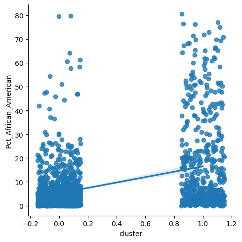

```python
sns.lmplot(x="cluster", y="Pct_African_American", data=df2, x_jitter=.15, y_jitter=.15);
```

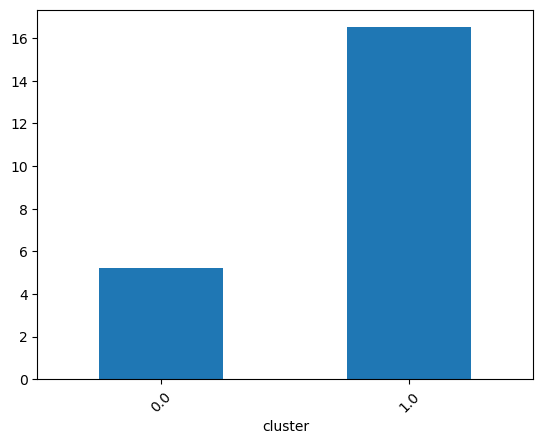

```python
df2.groupby('cluster')['Pct_African_American'].mean().plot(kind ='bar', rot=45)
```

## Which of the following statement is TRUE?

a. Schools in cluster 1, on average, have a higher percentage of African American students? - False

b. Schools in cluster 2, on average, have a higher percentage of African American students? - True, schools in cluster 2 have higher percentage of african americans.

## The mean values for "Pct_First_Language_Not_English" in each cluster. Also visualize it.

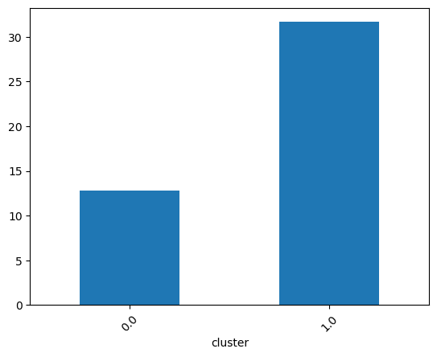

```python
df2.groupby('cluster')['Pct_First_Language_Not_English'].mean().plot(kind ='bar', rot=45)
```

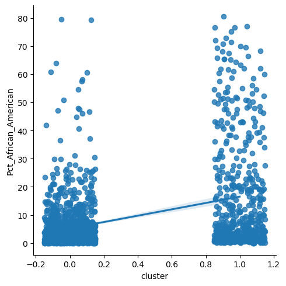

```python
sns.lmplot(x="cluster", y="Pct_African_American", data=df2, x_jitter=.15, y_jitter=.15);
```

## Which cluster has a higher percentage of economically disadvantaged students

- Cluster2

```python
df2.groupby('cluster')['Pct_Economically_Disadvantaged'].mean() #based on the result cluster 2 has a higher percentage of economically disadvantaged students.
```

```
cluster
0.0    25.222581
1.0    46.490577
Name: Pct_Economically_Disadvantaged, dtype: float64
```

# Build Decision Tree model (use the original data, not the normalizaed data)

```python
y = df2['cluster'].values
```

```python
X = df2.drop(['cluster'], axis=1)
```

```python
X.head()
```

|  | Pct_First_Language_Not_English | Pct_English_Language_Learner | Pct_Students_With_Disabilities | Pct_High_Needs | Pct_Economically_Disadvantaged | Pct_African_American | Pct_Asian | Pct_Hispanic | Pct_White | Pct_Native_American | Pct_Native_Hawaiian_Pacific_Isla | Pct_MultiRace_NonHispanic | Pct_Males | Pct_Females | Average_Class_Size |
| --- | --- | --- | --- | --- | --- | --- | --- | --- | --- | --- | --- | --- | --- | --- | --- |
| 0 | 5.3 | 2.4 | 9.7 | 28.8 | 21.5 | 2.2 | 1.5 | 9.1 | 85.8 | 0.2 | 0.2 | 0.9 | 45.6 | 54.4 | 15.8 |
| 1 | 10.5 | 7.2 | 13.3 | 37.1 | 23.3 | 1.9 | 1.9 | 6.7 | 88.4 | 0.5 | 0.2 | 0.3 | 50.2 | 49.8 | 24.6 |
| 2 | 12.8 | 3.0 | 21.2 | 34.0 | 16.3 | 3.9 | 3.0 | 8.4 | 84.7 | 0.0 | 0.0 | 0.0 | 54.2 | 45.8 | 14.6 |
| 3 | 5.5 | 1.8 | 13.1 | 30.8 | 21.6 | 2.4 | 1.8 | 6.1 | 89.3 | 0.0 | 0.0 | 0.3 | 53.4 | 46.6 | 21.1 |
| 4 | 5.9 | 2.0 | 10.8 | 30.6 | 22.7 | 2.0 | 1.4 | 4.2 | 92.1 | 0.0 | 0.0 | 0.3 | 50.7 | 49.3 | 30.4 |

```python
df2.isnull().sum() #Null values.
```

```
Pct_First_Language_Not_English       0
Pct_English_Language_Learner         0
Pct_Students_With_Disabilities       0
Pct_High_Needs                       0
Pct_Economically_Disadvantaged       0
Pct_African_American                 0
Pct_Asian                            0
Pct_Hispanic                         0
Pct_White                            0
Pct_Native_American                  0
Pct_Native_Hawaiian_Pacific_Isla     0
Pct_MultiRace_NonHispanic            0
Pct_Males                            0
Pct_Females                          0
Average_Class_Size                   0
cluster                             32
dtype: int64
```

```python
df2 = df2.dropna()
df2.isnull().sum()
```

```
Pct_First_Language_Not_English      0
Pct_English_Language_Learner        0
Pct_Students_With_Disabilities      0
Pct_High_Needs                      0
Pct_Economically_Disadvantaged      0
Pct_African_American                0
Pct_Asian                           0
Pct_Hispanic                        0
Pct_White                           0
Pct_Native_American                 0
Pct_Native_Hawaiian_Pacific_Isla    0
Pct_MultiRace_NonHispanic           0
Pct_Males                           0
Pct_Females                         0
Average_Class_Size                  0
cluster                             0
dtype: int64
```

```python
model = DecisionTreeClassifier()

model = model.fit(X, y)    # without model validation since this model is not for prediction, but for explanation

# check the accuracy on the training set
model.score(X, y)
```

```
1.0
```

```python
predicted_Y = model.predict(X)
print(predicted_Y)
```

```
[0. 0. 0. ... 1. 0. 1.]
```

## Plot tree with `tree.plot_tree`

- Use `figsize=(25,20)`
- To make the texts of the tree nodes more readable, you add `fontsize=16` into `tree.plot_tree` as another parameter.

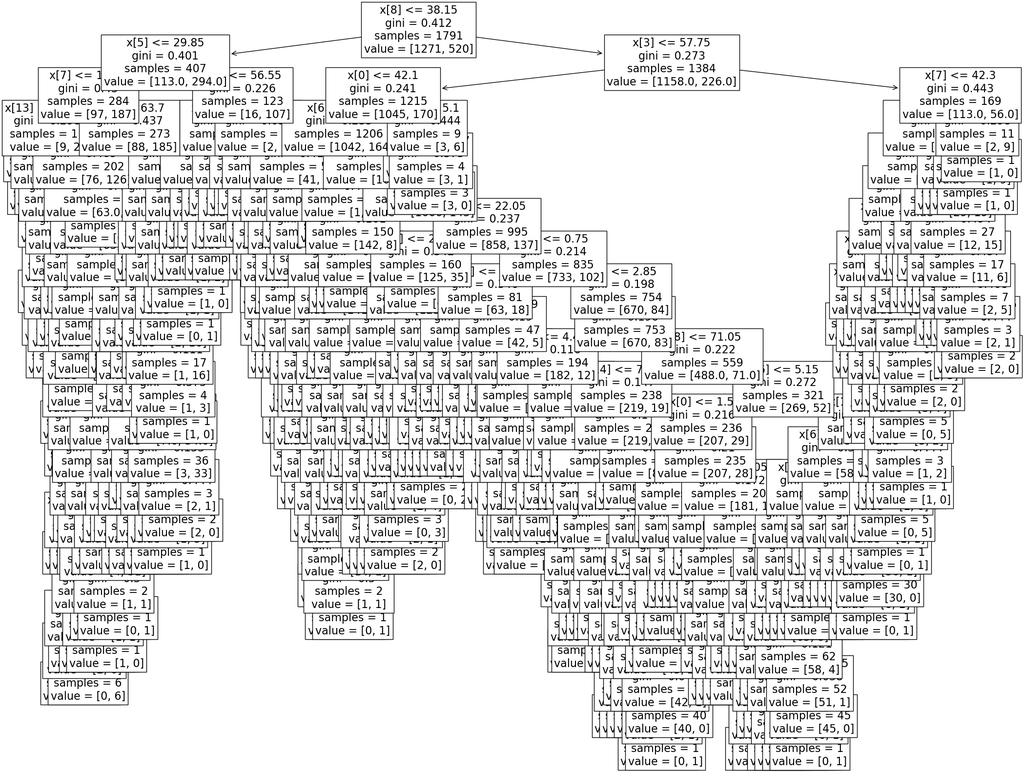

```python
plt.figure(figsize=(25,20))
tree.plot_tree(model,fontsize = 16);
```

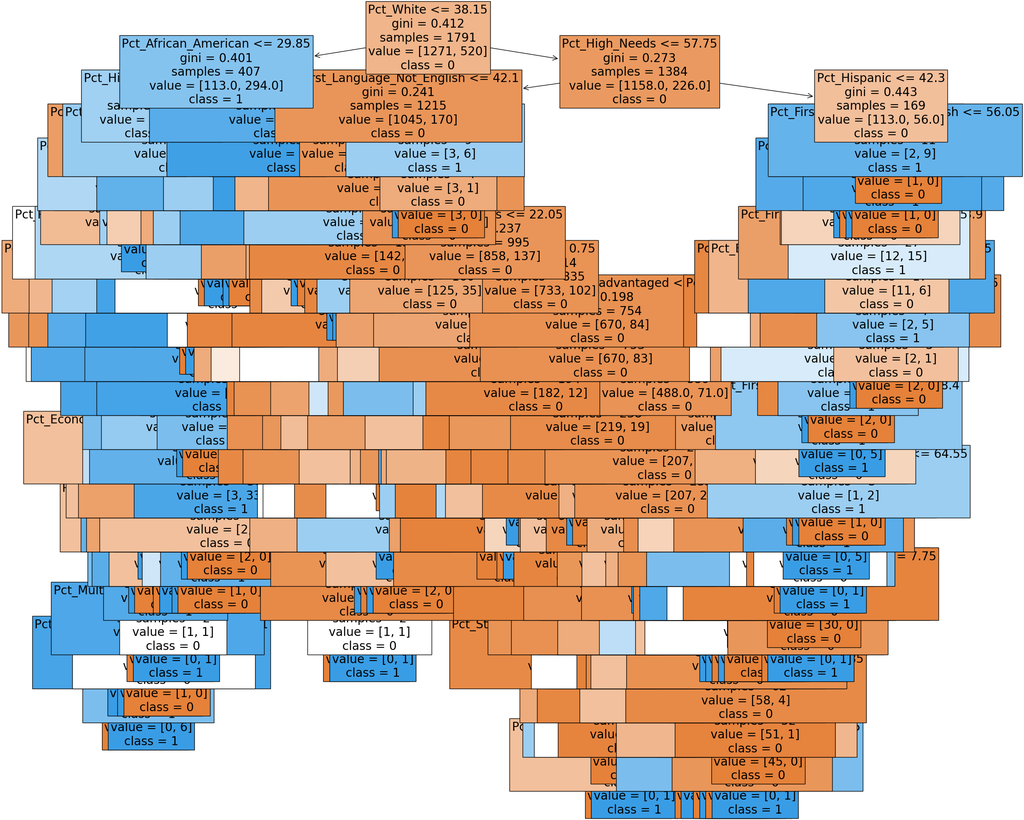

```python
plt.figure(figsize=(24,24))
tree.plot_tree(model,
               feature_names = X.columns,
               class_names=['0','1','2','3'],
               fontsize=20,
               filled = True);
```

## generate if-then rules using `export_text`

```python
text_representation = tree.export_text(model, feature_names=(list(X.columns)))
print(text_representation)
```

```
|--- Pct_White <= 38.15
|   |--- Pct_African_American <= 29.85
|   |   |--- Pct_Hispanic <= 11.95
|   |   |   |--- Pct_Females <= 42.55
|   |   |   |   |--- class: 1.0
|   |   |   |--- Pct_Females >  42.55
|   |   |   |   |--- Pct_Hispanic <= 2.05
|   |   |   |   |   |--- class: 1.0
|   |   |   |   |--- Pct_Hispanic >  2.05
|   |   |   |   |   |--- class: 0.0
|   |   |--- Pct_Hispanic >  11.95
|   |   |   |--- Pct_First_Language_Not_English <= 63.70
|   |   |   |   |--- Pct_MultiRace_NonHispanic <= 0.55
|   |   |   |   |   |--- Pct_African_American <= 8.00
|   |   |   |   |   |   |--- class: 0.0
|   |   |   |   |   |--- Pct_African_American >  8.00
|   |   |   |   |   |   |--- Pct_English_Language_Learner <= 20.50
|   |   |   |   |   |   |   |--- Pct_Economically_Disadvantaged <= 57.20
|   |   |   |   |   |   |   |   |--- class: 1.0
|   |   |   |   |   |   |   |--- Pct_Economically_Disadvantaged >  57.20
|   |   |   |   |   |   |   |   |--- Pct_English_Language_Learner <= 16.75
|   |   |   |   |   |   |   |   |   |--- class: 0.0
|   |   |   |   |   |   |   |   |--- Pct_English_Language_Learner >  16.75
|   |   |   |   |   |   |   |   |   |--- Pct_MultiRace_NonHispanic <= 0.25
|   |   |   |   |   |   |   |   |   |   |--- class: 1.0
|   |   |   |   |   |   |   |   |   |--- Pct_MultiRace_NonHispanic >  0.25
|   |   |   |   |   |   |   |   |   |   |--- class: 0.0
|   |   |   |   |   |   |--- Pct_English_Language_Learner >  20.50
|   |   |   |   |   |   |   |--- class: 1.0
|   |   |   |   |--- Pct_MultiRace_NonHispanic >  0.55
|   |   |   |   |   |--- Pct_Asian <= 25.05
|   |   |   |   |   |   |--- Pct_First_Language_Not_English <= 14.45
|   |   |   |   |   |   |   |--- Pct_Students_With_Disabilities <= 78.30
|   |   |   |   |   |   |   |   |--- Pct_English_Language_Learner <= 1.90
|   |   |   |   |   |   |   |   |   |--- class: 1.0
|   |   |   |   |   |   |   |   |--- Pct_English_Language_Learner >  1.90
|   |   |   |   |   |   |   |   |   |--- class: 0.0
|   |   |   |   |   |   |   |--- Pct_Students_With_Disabilities >  78.30
|   |   |   |   |   |   |   |   |--- class: 1.0
|   |   |   |   |   |   |--- Pct_First_Language_Not_English >  14.45
```

[output cut: 324 more lines]

```
|   |   |   |   |   |   |   |   |   |--- Pct_White >  51.15
|   |   |   |   |   |   |   |   |   |   |--- class: 0.0
|   |   |   |--- Pct_African_American >  20.15
|   |   |   |   |--- Pct_English_Language_Learner <= 28.05
|   |   |   |   |   |--- class: 1.0
|   |   |   |   |--- Pct_English_Language_Learner >  28.05
|   |   |   |   |   |--- class: 0.0
|   |   |--- Pct_Hispanic >  42.30
|   |   |   |--- Pct_First_Language_Not_English <= 56.05
|   |   |   |   |--- Pct_African_American <= 6.80
|   |   |   |   |   |--- class: 1.0
|   |   |   |   |--- Pct_African_American >  6.80
|   |   |   |   |   |--- class: 0.0
|   |   |   |--- Pct_First_Language_Not_English >  56.05
|   |   |   |   |--- class: 0.0
```

## Decision tree also shows the variables that are more important in creating clusters. Which variables are considered most important in this clustering analysis?

## Build randomforestclassifier model for feature importance

```python
# build randomforeastmodel

from sklearn.ensemble import RandomForestClassifier

clf = RandomForestClassifier(n_estimators=20)    #building 20 decision trees
clf=clf.fit(X, y)
clf.score(X,y)
```

```
0.9955332216638749
```

```python
pd.DataFrame({'feature':X.columns, 'importance':clf.feature_importances_})
```

|  | feature | importance |
| --- | --- | --- |
| 0 | Pct_First_Language_Not_English | 0.076093 |
| 1 | Pct_English_Language_Learner | 0.064684 |
| 2 | Pct_Students_With_Disabilities | 0.051948 |
| 3 | Pct_High_Needs | 0.102310 |
| 4 | Pct_Economically_Disadvantaged | 0.144473 |
| 5 | Pct_African_American | 0.083392 |
| 6 | Pct_Asian | 0.059614 |
| 7 | Pct_Hispanic | 0.091013 |
| 8 | Pct_White | 0.105786 |
| 9 | Pct_Native_American | 0.020795 |
| 10 | Pct_Native_Hawaiian_Pacific_Isla | 0.012579 |
| 11 | Pct_MultiRace_NonHispanic | 0.052312 |
| 12 | Pct_Males | 0.041722 |
| 13 | Pct_Females | 0.041512 |
| 14 | Average_Class_Size | 0.051767 |

- Based on the results above the most important features are economically disadvantaged,Pct_white,Pct high needs followed by Pct-hispanic and Pct_african.

## Which variables are considered least important in this clustering analysis?

- Pct_Native_Hawaiian_Pacific_Isla,Pct_Native_American, Pct_Males and Pct_FeMales are considered least important.

## Is the "average class size" considered important in this clustering analysis? Explain why.

- The average class size is not a very important feature as it holds same mean percentage in both the clusters. That means irrespective of the student type the average class size pretty much the same.

# Clustering analysis using AgglomerativeClustering (# of clusters = 2)

```python
np.random.seed(1) # setting random seed to get the same results each time.

agg= AgglomerativeClustering(n_clusters=2, linkage='ward').fit(X)
agg.labels_
```

```
array([0, 0, 0, ..., 0, 1, 1])
```

## Visualize dendrogram

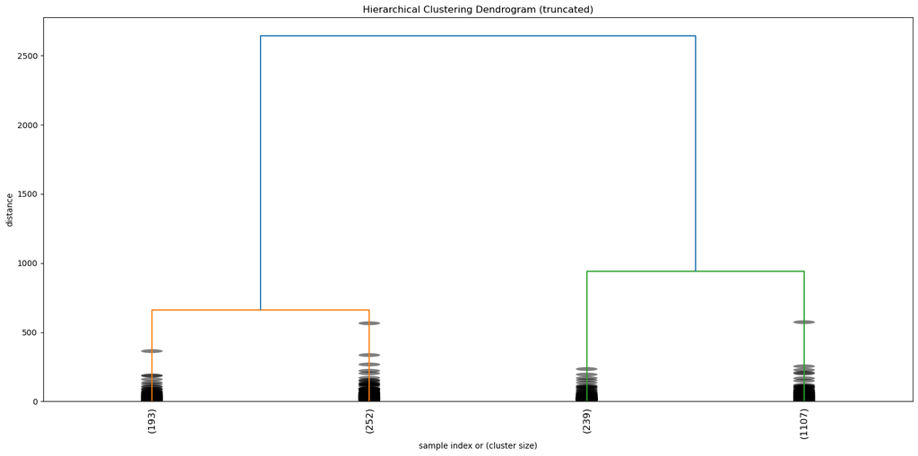

```python
#dendogram

plt.figure(figsize=(16,8))

plt.title('Hierarchical Clustering Dendrogram (truncated)')
plt.xlabel('sample index or (cluster size)')
plt.ylabel('distance')

linkage_matrix = ward(X)
dendrogram(linkage_matrix,
           truncate_mode='lastp',  # show only the last p merged clusters
           p=4,  # show only the last p merged clusters
           #show_leaf_counts=False,  # otherwise numbers in brackets are counts
           leaf_rotation=90.,
           leaf_font_size=12.,
           show_contracted=True,  # to get a distribution impression in truncated branches
           orientation="top")
plt.tight_layout() # fixes margins
```

## How many observations are in each cluster?

```python
#To add cluster label into the dataset as a column
df1 = pd.DataFrame(agg.labels_, columns = ['cluster'])
df1.head()
```

|  | cluster |
| --- | --- |
| 0 | 0 |
| 1 | 0 |
| 2 | 0 |
| 3 | 0 |
| 4 | 0 |

```python
df2 = df.join(df1)
df2.head()
```

|  | Pct_First_Language_Not_English | Pct_English_Language_Learner | Pct_Students_With_Disabilities | Pct_High_Needs | Pct_Economically_Disadvantaged | Pct_African_American | Pct_Asian | Pct_Hispanic | Pct_White | Pct_Native_American | Pct_Native_Hawaiian_Pacific_Isla | Pct_MultiRace_NonHispanic | Pct_Males | Pct_Females | Average_Class_Size | cluster |
| --- | --- | --- | --- | --- | --- | --- | --- | --- | --- | --- | --- | --- | --- | --- | --- | --- |
| 0 | 5.3 | 2.4 | 9.7 | 28.8 | 21.5 | 2.2 | 1.5 | 9.1 | 85.8 | 0.2 | 0.2 | 0.9 | 45.6 | 54.4 | 15.8 | 0.0 |
| 1 | 10.5 | 7.2 | 13.3 | 37.1 | 23.3 | 1.9 | 1.9 | 6.7 | 88.4 | 0.5 | 0.2 | 0.3 | 50.2 | 49.8 | 24.6 | 0.0 |
| 2 | 12.8 | 3.0 | 21.2 | 34.0 | 16.3 | 3.9 | 3.0 | 8.4 | 84.7 | 0.0 | 0.0 | 0.0 | 54.2 | 45.8 | 14.6 | 0.0 |
| 3 | 5.5 | 1.8 | 13.1 | 30.8 | 21.6 | 2.4 | 1.8 | 6.1 | 89.3 | 0.0 | 0.0 | 0.3 | 53.4 | 46.6 | 21.1 | 0.0 |
| 4 | 5.9 | 2.0 | 10.8 | 30.6 | 22.7 | 2.0 | 1.4 | 4.2 | 92.1 | 0.0 | 0.0 | 0.3 | 50.7 | 49.3 | 30.4 | 0.0 |

```python
df2.isnull().sum() #Null values.
```

[output not shown]

```python
df2 = df2.dropna()
df2.isnull().sum()
```

```
Pct_First_Language_Not_English      0
Pct_English_Language_Learner        0
Pct_Students_With_Disabilities      0
Pct_High_Needs                      0
Pct_Economically_Disadvantaged      0
Pct_African_American                0
Pct_Asian                           0
Pct_Hispanic                        0
Pct_White                           0
Pct_Native_American                 0
Pct_Native_Hawaiian_Pacific_Isla    0
Pct_MultiRace_NonHispanic           0
Pct_Males                           0
Pct_Females                         0
Average_Class_Size                  0
cluster                             0
dtype: int64
```

```python
df2.groupby('cluster').size() #1322 in cluster1 and 437 in cluster 2
```

```
cluster
0.0    1322
1.0     437
dtype: int64
```

```python
df2.groupby('cluster').mean()
```

| cluster | Pct_First_Language_Not_English | Pct_English_Language_Learner | Pct_Students_With_Disabilities | Pct_High_Needs | Pct_Economically_Disadvantaged | Pct_African_American | Pct_Asian | Pct_Hispanic | Pct_White | Pct_Native_American | Pct_Native_Hawaiian_Pacific_Isla | Pct_MultiRace_NonHispanic | Pct_Males | Pct_Females | Average_Class_Size |
| --- | --- | --- | --- | --- | --- | --- | --- | --- | --- | --- | --- | --- | --- | --- | --- |
| 0.0 | 13.008623 | 6.036687 | 17.692965 | 39.997579 | 25.621180 | 5.453177 | 5.953782 | 13.147958 | 71.426248 | 0.233207 | 0.096293 | 3.689486 | 51.721256 | 48.272390 | 18.296974 |
| 1.0 | 31.699542 | 17.462929 | 19.745309 | 62.513730 | 47.062243 | 17.316018 | 6.348284 | 33.887643 | 38.848284 | 0.230206 | 0.107094 | 3.266819 | 52.635927 | 47.360183 | 18.406178 |

## Compare the results from K-Mean clustering analysis and Agglomerative clustering analysis.

- Since we did 2 level clustering for both the models the mean value results are almost the same in both the cases. In both the cases the most important features are economically disadvantaged,Pct_white,Pct high needs followed by Pct-hispanic and Pct_african. But only difference is cluster centeroids generated bv each algorith while K-Mean algorithm generated cluster 1 with 1271 and cluster 2 has 520 whilst Agglomerative clustering algorithm generated with 1322 in cluster 1 and 437 in cluster 2. But the end result in clustering the data was similar in both cases.

Note: Several questions have been adapted from "SAS Enterprise Miner Exercise and Assignment Workbook by Varol Onur Kayhan"